# PI2_V2

Clustering

Groupe 88

2019-02-14 20:20:58

# Libraries

```r
library(tidyverse)  # data manipulation
library(cluster)    # clustering algorithms
library(factoextra) # clustering algorithms & visualization
library(FactoMineR)
library(gridExtra)
library(fpc)
library(dbscan)
library(mclust)
library(adamethods)
library(car) # Companion to Applied Regression
library(caret)
library(randomForest)
library(mlbench)
library(fpc)
```

# Dataset importation

```r
Dataset = function()
{
  # n is the number of outliers to remove
  df = read.csv("Last.csv", row.names = 1, sep = ';')

  # Omit non available values if there are any left (pre-treated dataset)
  df <- na.omit(df)

  # Feature scaling through standardization is an important preprocessing step for many machine learning algorithms. Standardization involves rescaling the    features such that they have the properties of a standard normal distribution with a mean of 0 and a standard deviation of 1. It helps to normalise the      data within a particular range and it can also help in speeding up the calculations in the algorithms.
  df <- scale(df)

  return (df)
}
```

```r
df = Dataset()
```

Remove Redundant Features Generally, you want to remove attributes with an absolute correlation of 0.75 or higher.

```r
# ensure the results are repeatable
#set.seed(7)
# calculate correlation matrix
#correlationMatrix <- cor(df)
# summarize the correlation matrix
#print(correlationMatrix)
# find attributes that are highly corrected (ideally >0.75)
#highlyCorrelated <- findCorrelation(correlationMatrix, cutoff=0.75)
# print indexes of highly correlated attributes
#print(highlyCorrelated)
```

# Outlier Treatment

Outliers can drastically bias/change the fit estimates and predictions.

## Detect outliers

Multivariate Model Approach

```r
new.df = as.data.frame.matrix(df)

mod <- lm(new.df$Pre.Tax.ROE ~ ., data = new.df)
```

## Cook’s distance outlier test

Declaring an observation as an outlier based on just one feature could lead to unrealistic inferences. When you have to decide if an individual entity is an extreme value or not, it is better to collectively consider the features (X’s) that matter -> Using Cook’s Distance.

Cook’s distance is a measure computed with respect to a given regression model and therefore is impacted only by the X variables included in the model. But, what does cook’s distance mean? It computes the influence exerted by each data point (row) on the predicted outcome.

where :

Y^j is the value of jth fitted response when all the observations are included. Y^j(i) is the value of jth fitted response, where the fit does not include observation i. MSE is the mean squared error. p is the number of coefficients in the regression model.

In general use, the observations that have a cook’s distance greater than 4 times the mean may be classified as influential.

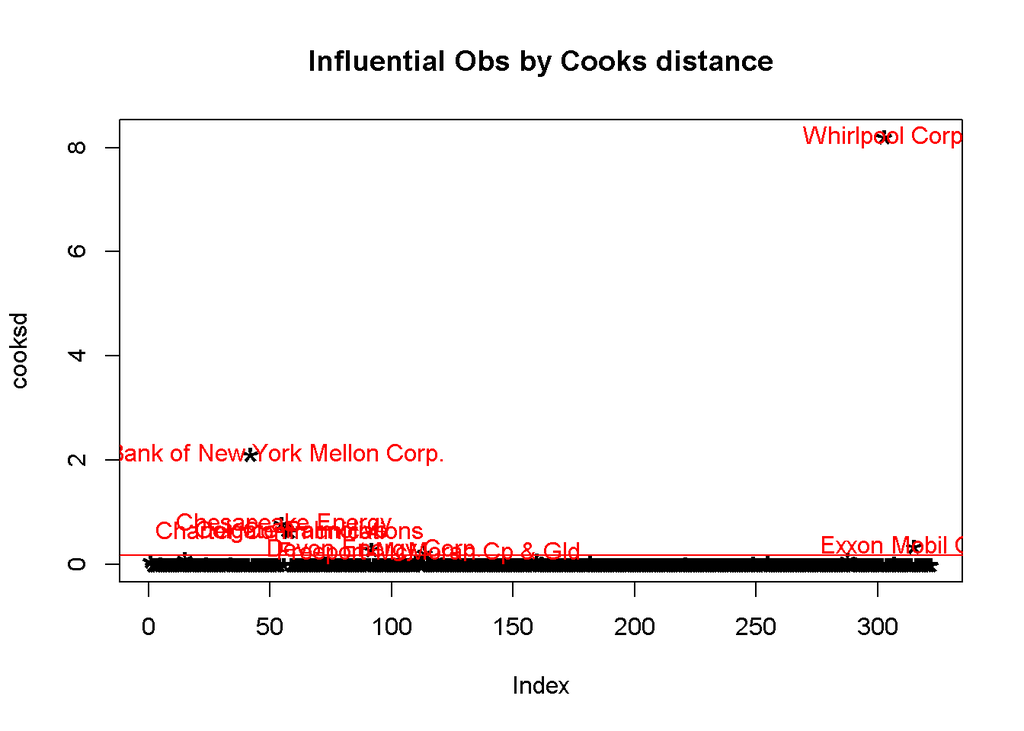

```r
cooksd <- cooks.distance(mod)

plot(cooksd, pch="*", cex=2, main="Influential Obs by Cooks distance")  # plot cook's distance
abline(h = 4*mean(cooksd, na.rm=T), col="red")  # add cutoff line
text(x=1:length(cooksd)+1, y=cooksd, labels=ifelse(cooksd>4*mean(cooksd, na.rm=T),names(cooksd),""), col="red")  # add labels
```

```r
influential <- names(cooksd)[(cooksd > 4*mean(cooksd, na.rm=T))]
#new.df[influential, ]
```

Get company indexes (vector of indexes)

```r
CompanyIndex = function(Df, vect)
{
  indexes = 0

  for (i in 1:length(vect))
  {
    indexes[i] = which(rownames(Df) == vect[i])
  }

  return (indexes)
}
```

```r
outliers1 = CompanyIndex(Dataset(), influential)
outliers1
```

```
## [1]  42  55  57  58  92 114 303 315
```

## Companion to Applied Regression outlier test

The function outlierTest from car package (Companion to Applied Regression) gives the most extreme observation based on the given model.

```r
car_outliers = outlierTest(mod)

vect = names(car_outliers$rstudent)

outliers2 = CompanyIndex(df, vect)

car_outliers
```

```
##                         rstudent unadjusted p-value Bonferonni p
## Colgate-Palmolive      17.365492         1.1415e-46   3.6755e-44
## Charter Communications -7.473355         9.4988e-13   3.0586e-10
## Masco Corp.             6.531670         2.9518e-10   9.5047e-08
## Chesapeake Energy      -5.095146         6.3276e-07   2.0375e-04
## Allegion               -4.265940         2.7059e-05   8.7129e-03
## Whirlpool Corp.         4.073536         5.9965e-05   1.9309e-02
```

```r
outliers2
```

```
## [1]  58  57 182  55  15 303
```

## Euclidean distance outlier test

The function takes for parameters a dataframe, the number of outliers to detect and the number of centers for the k-means clustering.

First, it will do a PCA : -statistical procedure that uses an orthogonal transformation to convert a set of observations of possibly correlated variables into a set of values of linearly uncorrelated variables called principal components. -consiste à transformer des variables corrélées en nouvelles variables décorrélées les unes des autres. Ces nouvelles variables sont nommées « composantes principales », ou axes principaux. Elle permet de réduire le nombre de variables et de rendre l’information moins redondante.

In the next step we will calculate the distance (Euclidean) between the objects and cluster centers to determine the outliers and identify n largest distances which are outliers.

Finally we plot the graph with c clusters et n outliers detected we can remove later on for our final clustering.

Get outliers (vector of n indexes of the outliers):

```r
Outliers = function(Df, n, c)
{
  #parameters : Df = dataframe, n = number of outliers, c = number of centers for clustering
  PCA_Data = princomp(Df, cor = T)
  PC1 = PCA_Data$scores[,1]
  PC2 = PCA_Data$scores[,2]

  X = cbind(PC1, PC2)
  km = kmeans(X, centers = c)

  centers = km$centers[km$cluster,]
  distances = sqrt(rowSums((X-centers)^2))
  outliers = order(distances, decreasing = T)[1:n]

  plot(X, pch = 16, col = km$cluster, cex = 1, main = paste0("C = ", c, "     N = ", n))
  points(km$centers, pch = 23, bg = "yellow", cex = 2, lwd = 2)
  points(X[outliers,], pch = 25, col = "orange", cex = 2)
  legend("topleft", legend = c("Cluster center", "Outliers"), pt.cex = 2, pch = c(23, 25), col = c("black", "orange"), pt.bg = c("yellow", NA))

  return (outliers)
}
```

```r
outliers3 = Outliers(df,30,1)
```

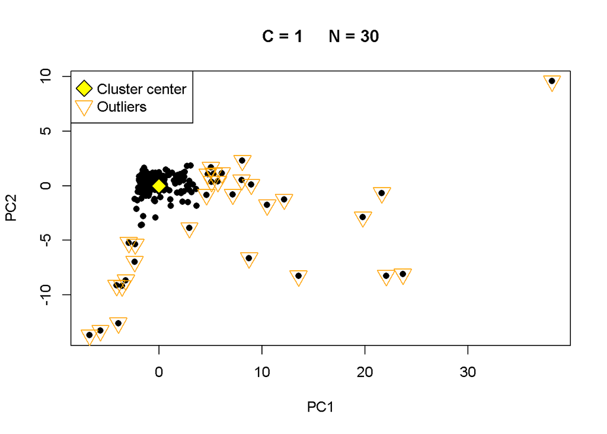

```r
outliers3
```

```
##  [1]   3 315 264 307 298  73  55  92 206 199  42 111 114 312  24 146 123
## [18] 150 217 221  82 319 101  67  34 136 220 249 288 198
```

## kNN outlier test

Description: k-nearest neighbors outlier detection method (kNNo). Each point’s anomaly score is the distance to its kth nearest neighbor in the data set. Then, all points are ranked based on this distance. The higher an example’s score is, the more anomalous it is.

Usage: do_knno(data, k, top_n)

Arguments: data Data observations. k Number of neighbors of a point that we are interested in. top_n Total number of outliers we are interested in.

```r
outliers4 = do_knno(df, 10, 10)
outliers4
```

```
##  [1]   3 315  42 264 307 298  73 206  55  92
```

We can now remove the outliers from de dataset and begin the clustering methods.

```r
dataset = df[-outliers3,]
data = as.data.frame.matrix(dataset)
```

# Clustering

## Preview

Preview with 2, 3 and 4 centers to get some insights.

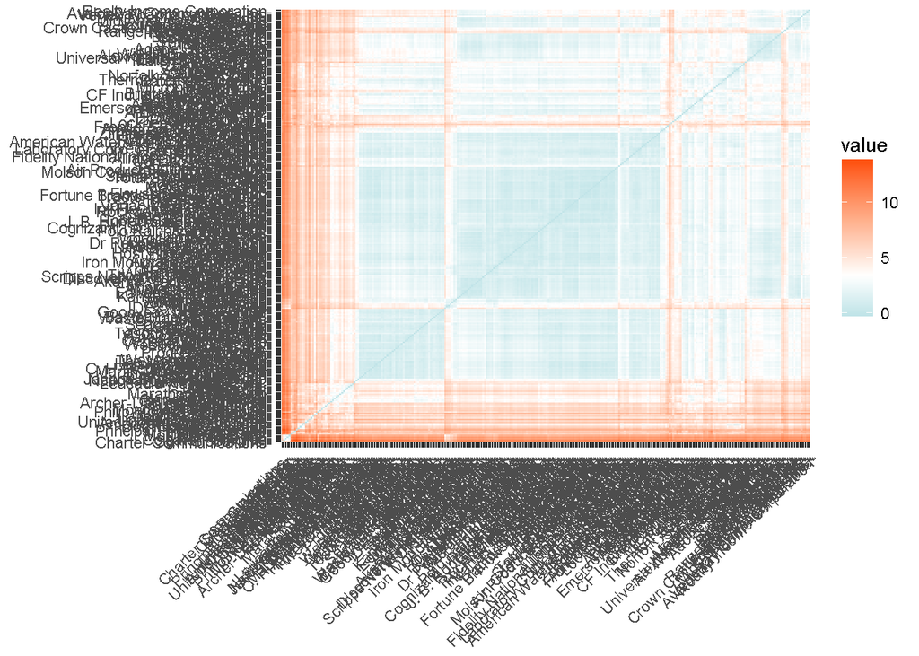

```r
distance <- get_dist(dataset)
fviz_dist(distance, gradient = list(low = "#00AFBB", mid = "white", high = "#FC4E07"))
```

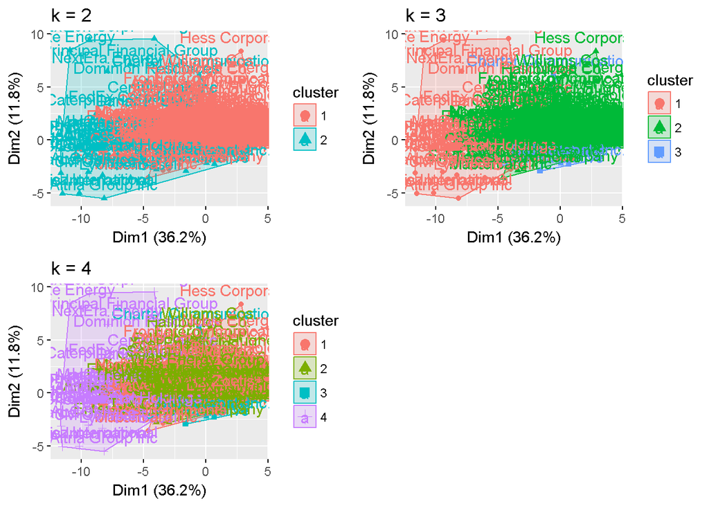

```r
k2 <- kmeans(dataset, centers = 2, nstart = 25)
p1 = fviz_cluster(k2, data = dataset) + ggtitle("k = 2")

k3 = kmeans(dataset, centers = 3, nstart = 25)
p2 = fviz_cluster(k3, data = dataset) + ggtitle("k = 3")

k4 = kmeans(dataset, centers = 4, nstart = 25)
p3 = fviz_cluster(k4, data = dataset) + ggtitle("k = 4")

grid.arrange(p1, p2, p3, nrow = 2)
```

## Optimal number of clusters

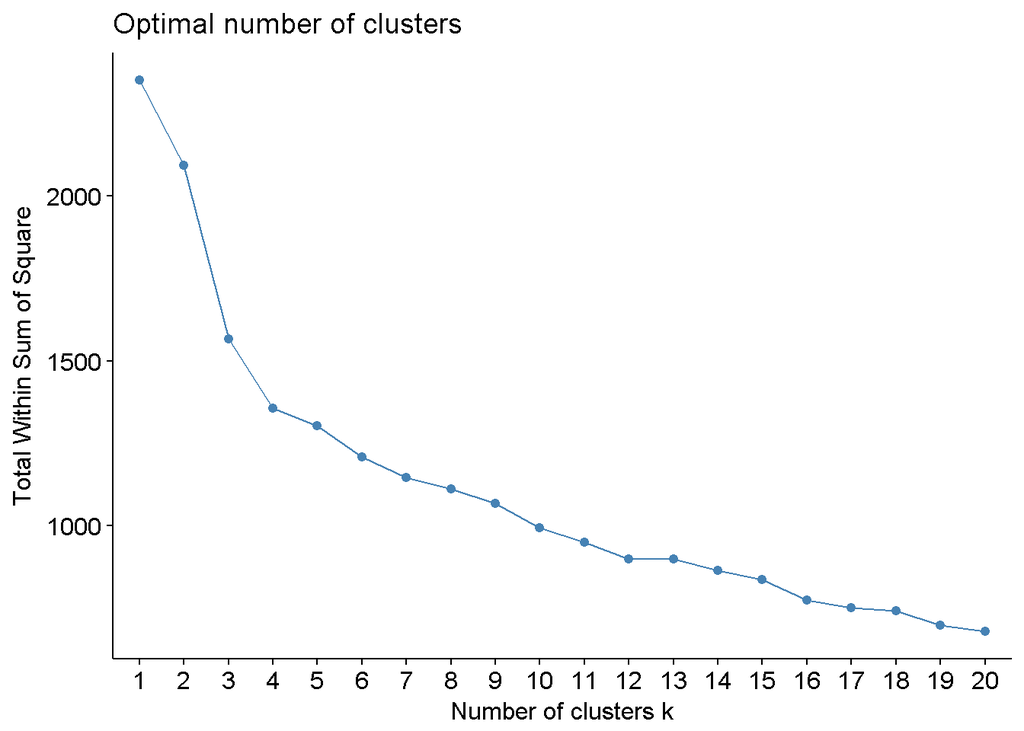

```r
set.seed(123)

fviz_nbclust(dataset, kmeans, method = "wss", k.max = 20)
```

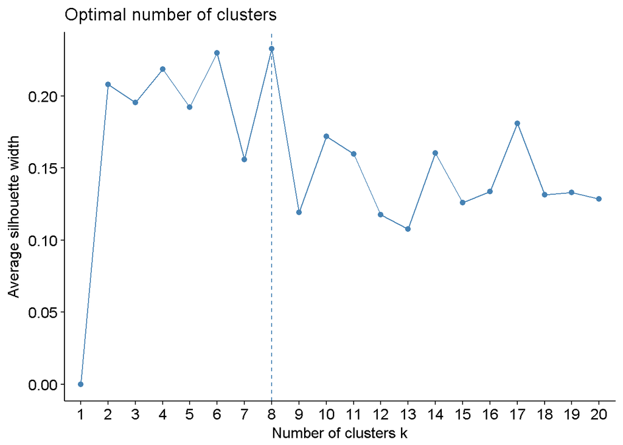

```r
fviz_nbclust(dataset, kmeans, method = "silhouette", k.max = 20)
```

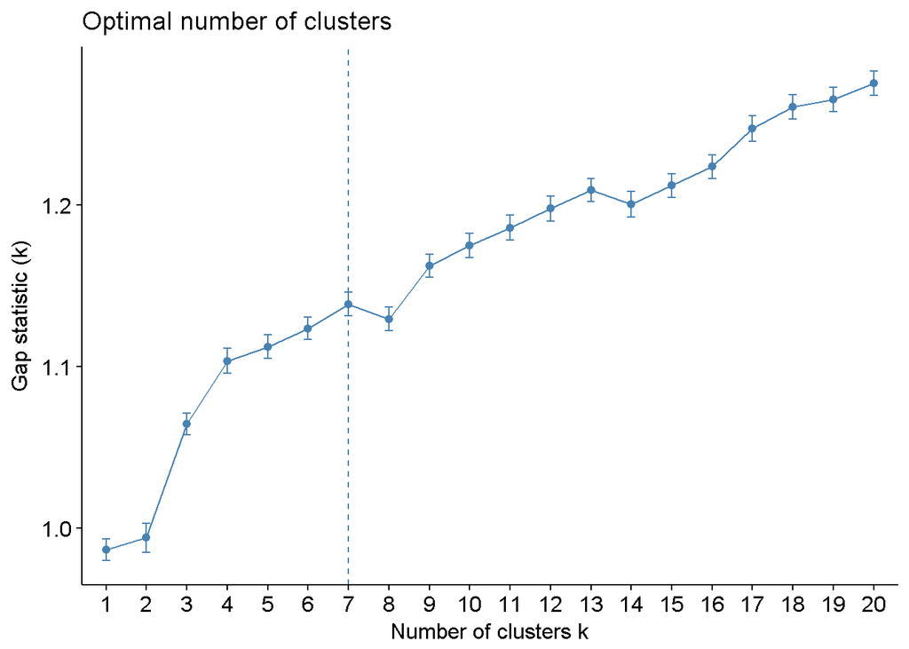

```r
fviz_nbclust(dataset, kmeans, method = "gap_stat", k.max = 20)
```

## Clustering methods

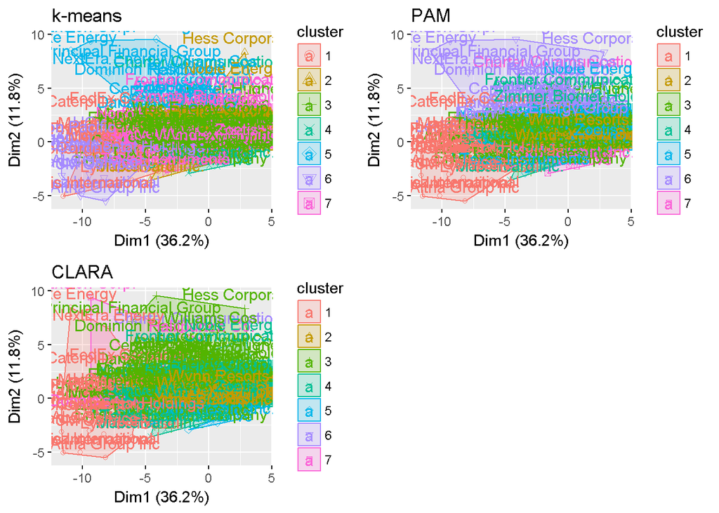

```r
# Compute k-means
k = kmeans(dataset, centers = 7, nstart = 25)
a1 = fviz_cluster(k, data = dataset) + ggtitle("k-means")

# Compute PAM
pam <- pam(dataset, 7)
a2 = fviz_cluster(pam) + ggtitle("PAM")

# Compute CLARA
clara <- clara(dataset, 7, samples = 50, pamLike = TRUE)
a3 = fviz_cluster(clara) + ggtitle("CLARA")

grid.arrange(a1, a2, a3, nrow = 2)
```

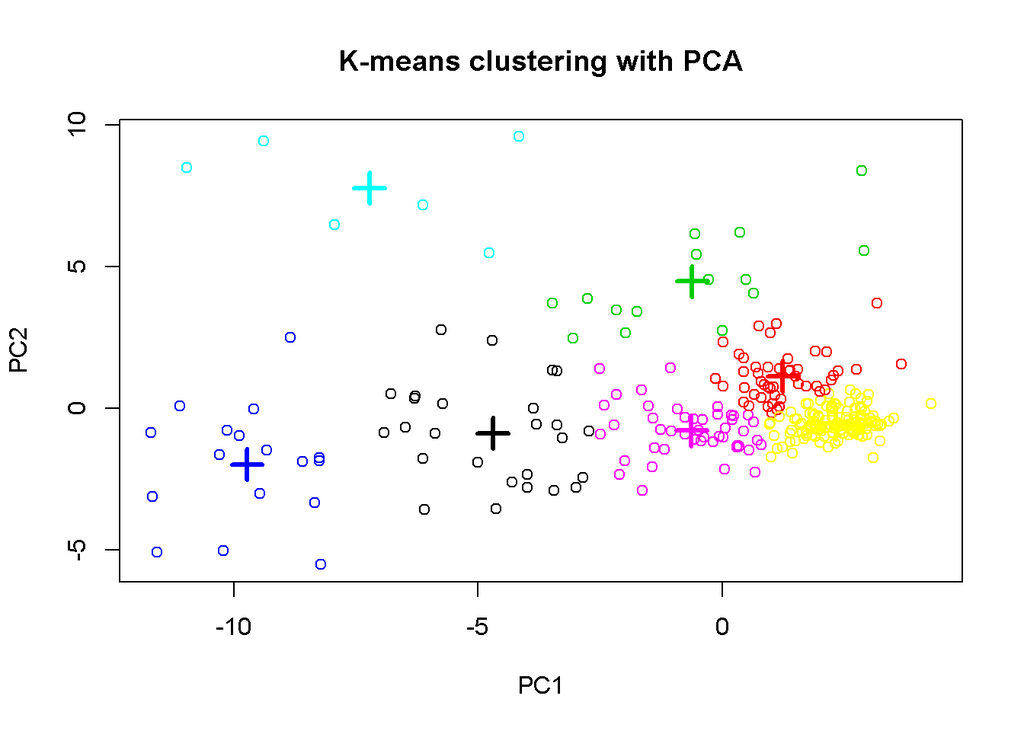

```r
PCA_Data = princomp(dataset, cor = T)

#str(PCA_Data)
#summary(PCA_Data)

PC1 <- PCA_Data$scores[,1]
PC2 <- PCA_Data$scores[,2]

X <- cbind(PC1, PC2)
km <- kmeans(X, centers = 7)
plot(PC1, PC2, col = km$cluster, xlab = "PC1", ylab = "PC2", main = "K-means clustering with PCA")
points(km$centers, col = 1:7, pch = 3, cex = 2, lwd = 3)
```

```r
OrderClust = function(clust)
{
  o = order(clust$cluster)
  kmclust = data.frame(clust$cluster[o])
  return (kmclust)
}
```

```r
d1 = OrderClust(km)
d2 = OrderClust(pam)
d3 = OrderClust(clara)

result = cbind(d1, d2, d3)
```

## Clustering test

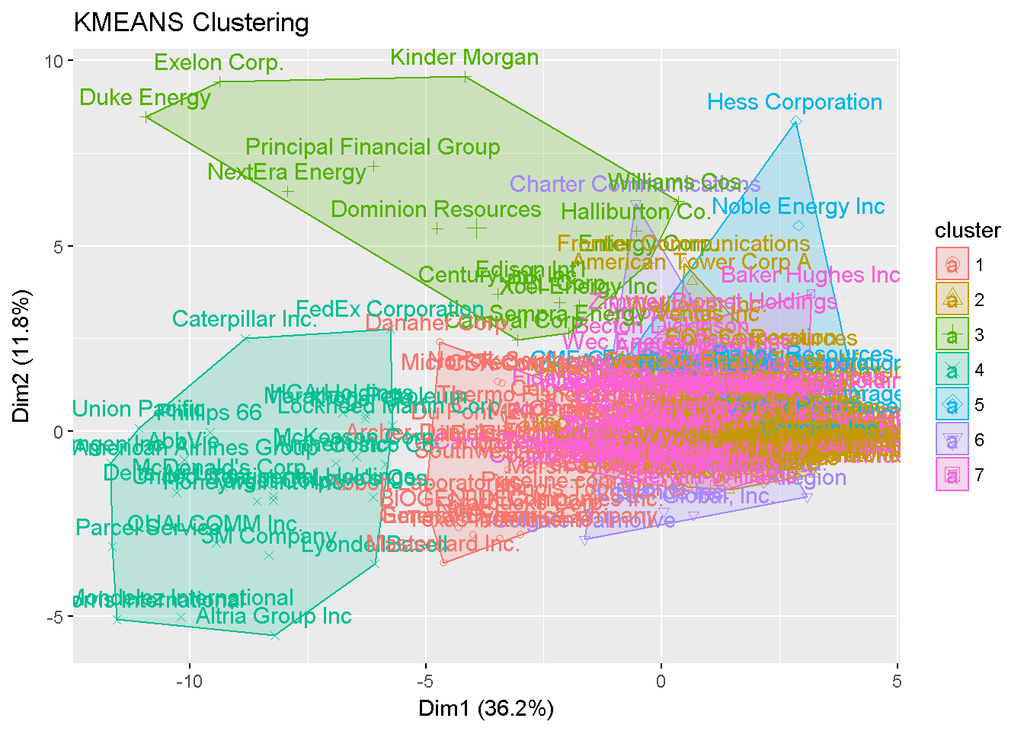

```r
set.seed(123)

res1 = data %>%
scale() %>%
eclust("kmeans", k = 7, graph = TRUE)
```

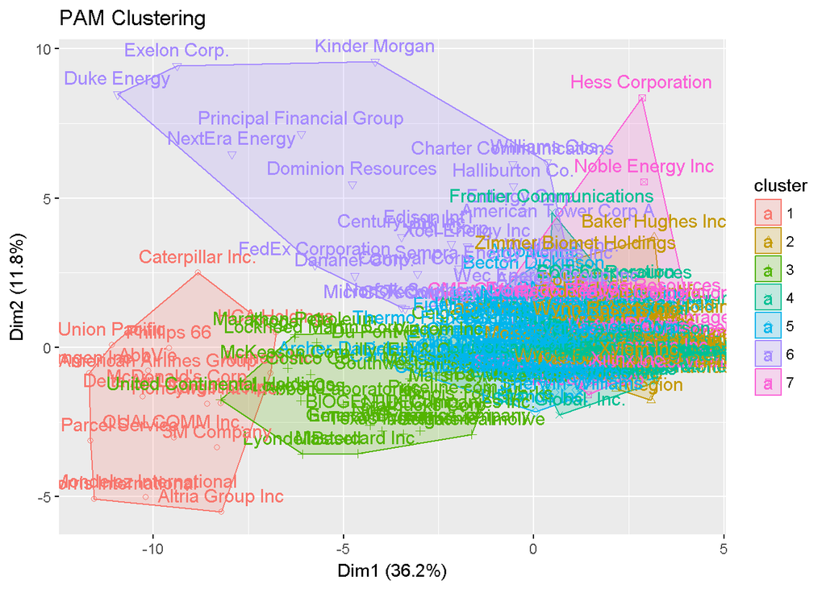

```r
res2 = data %>%
scale() %>%
eclust("pam", k = 7, graph = TRUE)
```

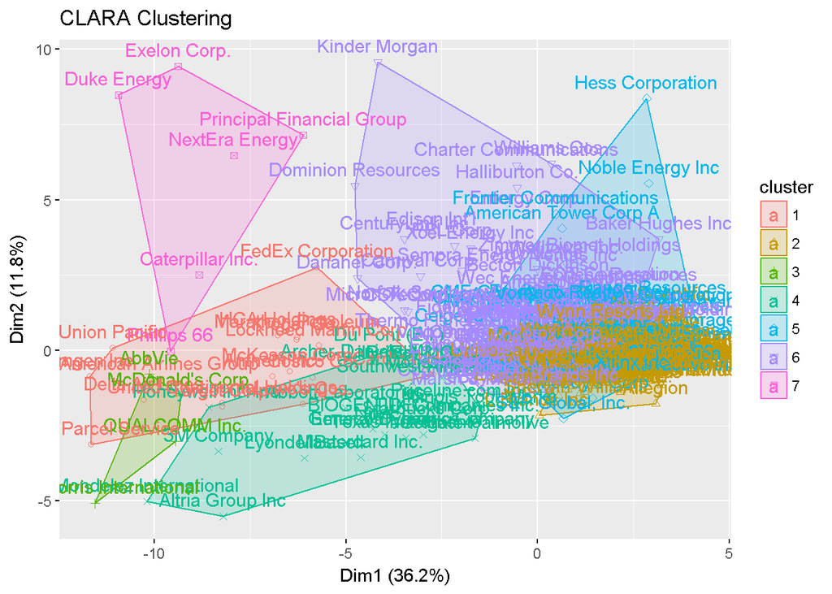

```r
res3 = data %>%
scale() %>%
eclust("clara", k = 7, graph = TRUE)
```

```r
s1 = fviz_silhouette(res1)
```

```
##   cluster size ave.sil.width
## 1       1   30          0.05
## 2       2  102          0.20
## 3       3   15         -0.02
## 4       4   27         -0.04
## 5       5   11          0.05
## 6       6    6          0.22
## 7       7  101          0.10
```

```r
s2 = fviz_silhouette(res2)
```

```
##   cluster size ave.sil.width
## 1       1   18          0.00
## 2       2   57          0.18
## 3       3   28         -0.06
## 4       4   75          0.16
## 5       5   67          0.00
## 6       6   26         -0.11
## 7       7   21         -0.01
```

```r
s3 = fviz_silhouette(res3)
```

```
##   cluster size ave.sil.width
## 1       1   17         -0.02
## 2       2  113          0.45
## 3       3    4         -0.01
## 4       4   23          0.06
## 5       5   47         -0.09
## 6       6   82         -0.13
## 7       7    6          0.02
```

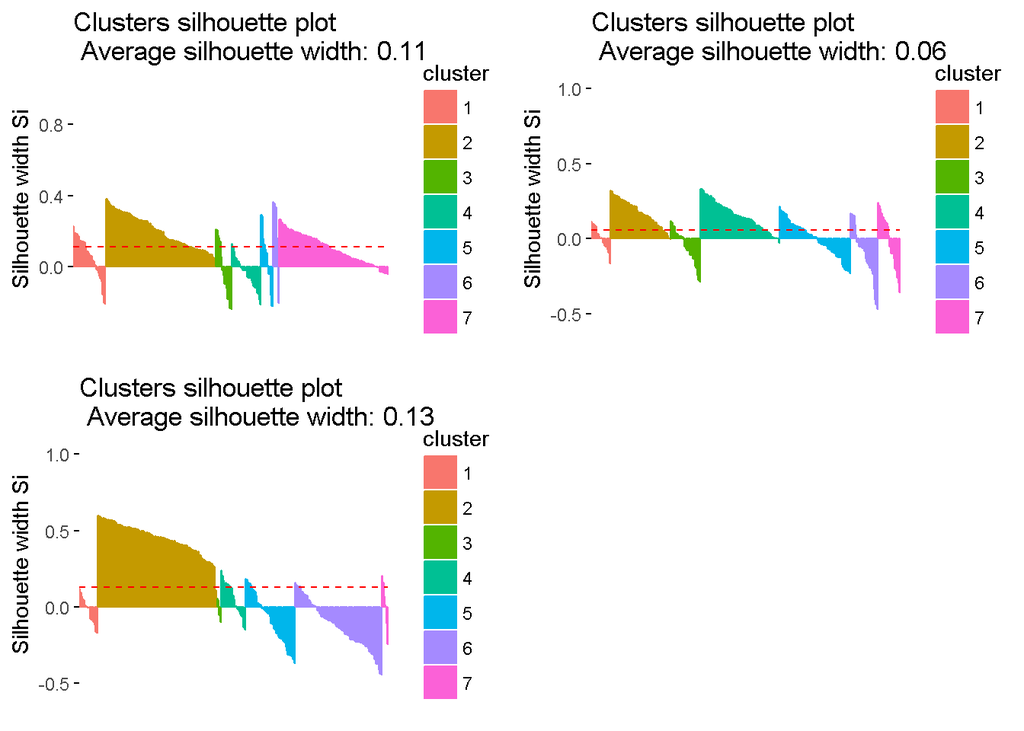

```r
grid.arrange(s1, s2, s3, nrow = 2)
```